# Project 2: Data Mining, Classification, Prediction

SDS322E

# Mining, Classification, Prediction

## Mark Moreno and mam24932 here

### Introduction

```r
library(tidyverse)

RAPTORDATA <- read_csv(file = "modern_RAPTOR_by_player.csv")
ALLSTARS <- read.csv("NBA All Star Games (1).csv")
mpg <- read.csv("mpgstats.csv")
mpg <- mpg %>% distinct()

RAPTORDATA <- RAPTORDATA %>% filter(season == 2016)  ## fitlers to a single season
ALLSTARS <- read.csv("NBA All Star Games (1).csv")
ALLSTARS <- ALLSTARS %>% filter(Year == 2016)
ALLSTARS <- ALLSTARS %>% select(1:3)


ALLSTARS <- ALLSTARS %>% rename(player_name = Player)
df <- left_join(RAPTORDATA, ALLSTARS)
df <- df %>% select(-22)
df$Selection.Type <- as.logical(df$Selection.Type)
df[is.na(df)] <- FALSE
# gives us the all stars in logical vector
df <- left_join(mpg, df)
df <- df %>% drop_na()
df <- df %>% mutate(starter = MPG > 25.5)  #creating a group for starters and non-starters (logical)
df %>% count(starter)
```

```
##   starter   n
## 1   FALSE 364
## 2    TRUE 154
```

```r
df <- df %>% distinct(player_name, .keep_all = T)  #REMOVES DUPLICATE PLAYERS

df <- df %>% filter(mp > 100)  #removes players who did not play many games
dfnames <- df
```

This data is important to me because I have always been a basketball fan and want to see what it takes to become a great player in the league. This analysis will help me understand what types of impacts some of the best players in the league have. I chose the RAPTOR dataset because it is well known to be one of the best ways to analyze basketball player performance with many different measurements of their skill. I wanted to add a binary variable that was for just the players who made the all-star game so I used left Join to create a new data frame with both the analytic data and also whether they had become an all-star or not. I also added whether they were a starter or not to see how it matched up with our clusters that were created.

### Cluster Analysis

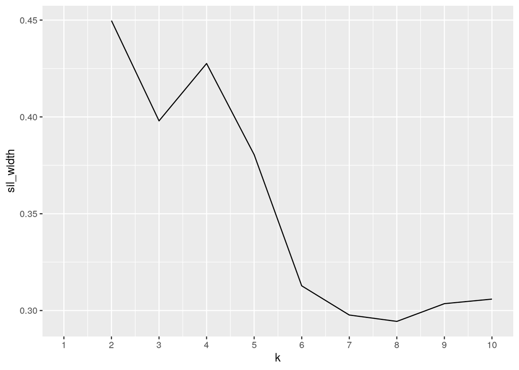

```r
library(cluster)

pam_dat <- df %>% select(raptor_total, war_total, pace_impact,
    predator_total)
sil_width <- vector()
for (i in 2:10) {
    pam_fit <- pam(pam_dat, k = i)
    sil_width[i] <- pam_fit$silinfo$avg.width
}
ggplot() + geom_line(aes(x = 1:10, y = sil_width)) + scale_x_continuous(name = "k",
    breaks = 1:10)
```

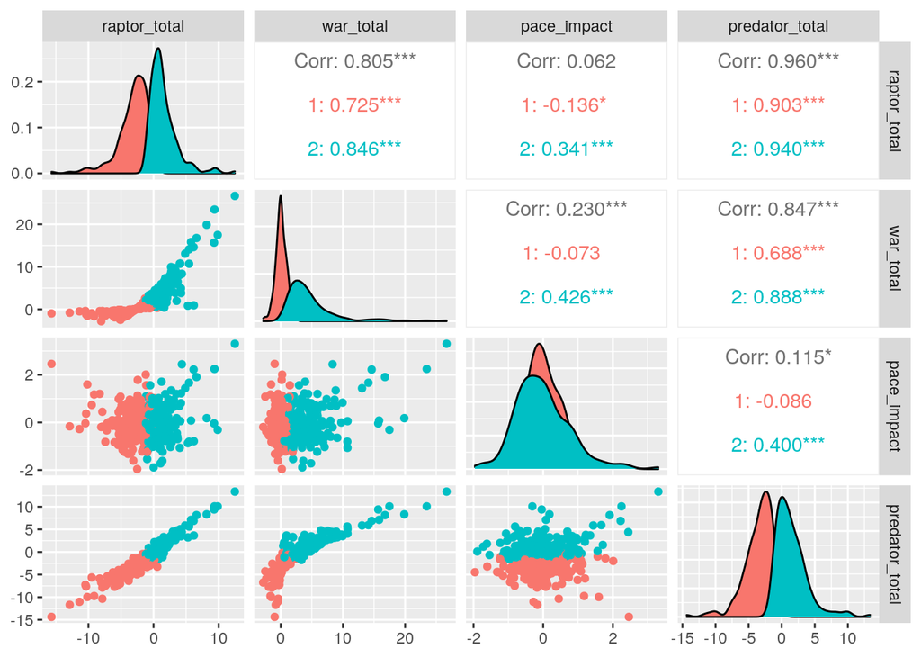

```r
# 2 was the best choice for all of the different variables
# maximizing the sil width.

library(cluster)  #load the cluster package
pam1 <- df %>% select(raptor_total, war_total, pace_impact, predator_total) %>%
    pam(k = 2)  #use the pam function
library(GGally)
df %>% mutate(cluster = as.factor(pam1$clustering)) %>% ggpairs(columns = c("raptor_total",
    "war_total", "pace_impact", "predator_total"), aes(color = cluster))
```